# A gentle introduction to R and GPUs

2017-12-07

## GPUs and R Workshop

Todays Agenda

- What/why GPUs
- ARC GPU resources
- GPU computing - Programming languages
- Ways to use access the GPUs through R
  - R packages
  - CUDA/OpenCL libraries
  - Directives
  - CUDA/OpenCL/etc
- Beginner R-GPU - R GPU packages
  - matrix multiply
  - Solve

## GPUs and R Workshop cont.

- Intermediate R-GPU - CUDA/OpenCL libraries
  - Vector add
  - Matrix multiply
- Discuss generalized computations
  - Programming Model
  - Memory
  - Variable casting
- Writing/wrapping your own CUDA/OpenCL code
  - example
- Profiling GPU use

## Introduction

### Acknowledgements and Inspirations

The following sources were used in part or as inspiration:

- ARC presentation on CUDA https://www.arc.vt.edu/userguide/cuda/
- NVIDIA accelerate R (lots of good stuff here)  
  https://devblogs.nvidia.com/parallelforall/accelerate-r-applications-cuda/
- Berkely GPU Workshop 2016 (most awesome writeup!!)  
  https://github.com/berkeley-scf/gpu-workshop-2016
- r-tutor GPU section  
  http://www.r-tutor.com/gpu-computing
- r-bloggers GPU programming with gpur  
  https://www.r-bloggers.com/r-gpu-programming-for-all-with-gpur/
- parallelr.com computing with gpuR  
  http://www.parallelr.com/r-gpu-programming-for-all-with-gpur/
- really nice presentation on NVIDA CUDA programming <http://people.math.umass.edu/~johnston/M697S12/ CUDA_threads_and_block_scheduling.pdf>

## Why GPUs??

CPU trends – KarlRupp.net

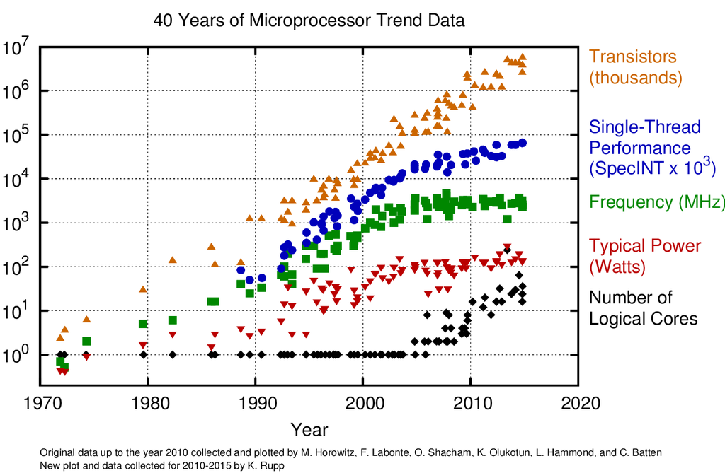

## So, why GPUs??

You need your code to go faster, you have a few options:

- Be a more efficient programmer
  - use vector/matrix operations
  - remove redundant operations
  - avoid memory copy/preallocate
- Port your code to C/C++/Fortran
  - full Monte (.C or .Call)
  - Rcpp
- Parallelize, ie use more cores
  - parallel packages
  - MPI
  - GPU…

## What are GPUs?

GPU = Graphics Processing Unit  
GPGU = General Purpose GPU

- Where a CPU may have 2-36 cores, a typical GPU will have 100-1000's of cores. The Tesla P100 GPU has 3584 cores.

[figure not shown]

Tesla P100

## What do GPUs do better than CPUs

Think massively parallel vanilla compute, like updating a picture across a billion pixels …

- For situations where the same calculation is done across many slices of a dataset or problem, the massive parallelism of a GPU may be useful (SIMD).
- Nothing comes for free, here we lose memory and suffer from data transfer from system to GPU (and likely back). IE, not all programming situations are appropriate for GPU devices. A high end GPU has 16-32 GB on card memory which may limit the utility of GPUs in some situations. More on this later.

## Basic example – pi (1)

Ratio of areas of unit circle (C) and unit square (S). Calculate areas by "throwing darts" and counting the times the darts are found in circle and square

\[ \begin{eqnarray*} \frac{C}{S} & = & \frac{\pi r^2}{(2r)^2}=\frac{\pi}{4} \\ \pi & = & \frac{4C}{S} \end{eqnarray*} \]

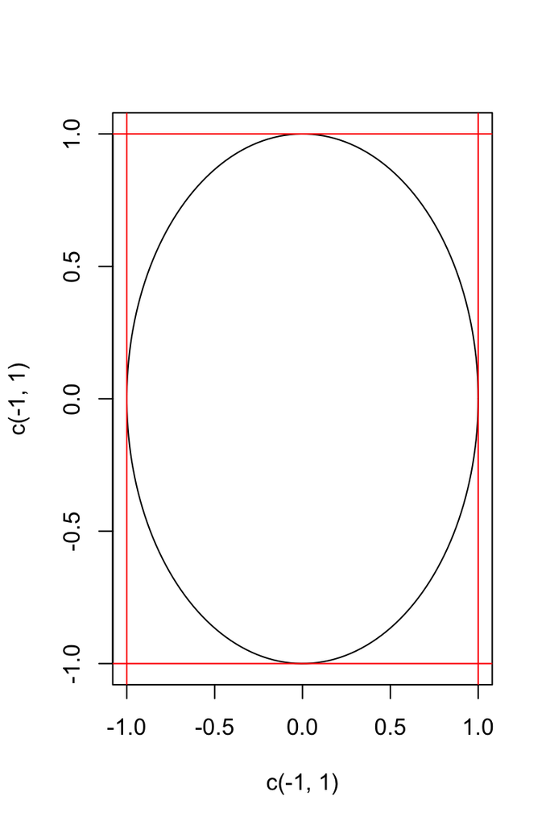

## Basic example – pi (1)

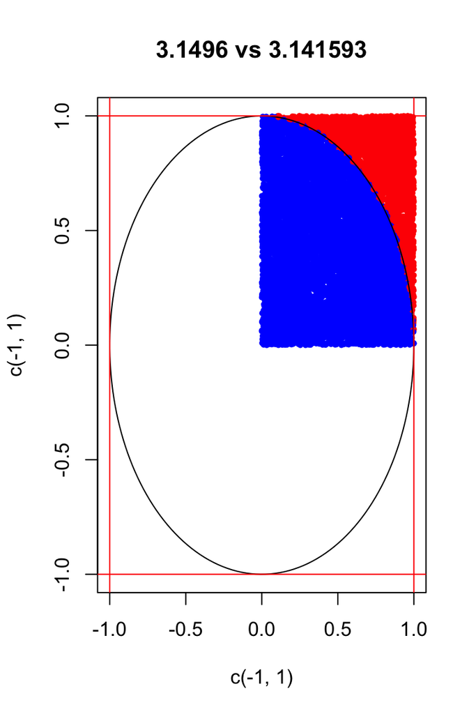

## Basic example – pi (2)

Monte carlo integrate area in circle and use formula.

\[ \begin{eqnarray*} \frac{area}{4} & = & \int_0^{1} \sqrt{1-x^2} dx \\ & \approx & \sum_{x_i \in U(0,1), i = [1 \dots N]} \frac{\sqrt{1-x^2}}{N} \end{eqnarray*} \]

Turns out, this is requires a LOT of points to get to a reasonable accuracy. Depending on how you do it, to get a stable estimate of pi to 5 decimal places may require \(10^8-10^{11}\) random numbers. Using the above in a single go, we get pi=3.141713 vs 3.141593. Good example for GPUs???

## Basic example – pi (3)

Buffon's needle (hotdog) toss:

Toss hotdogs to ground with a ladder of evenly spaced lines layed out. IF the spacing of the lines is the same as the length of the hotdog, we get:

\[\pi = \frac{2nH}{kL} = \frac{2*tosses}{crosses}\]

Good example for GPUs???

Using the above, with number of tossed dogs equal \(10^6\), we get pi=3.1431649 vs 3.141593. What if we wanted more accuracy or if we wanted to explore hotdog length (H) and line spacing (L)? Now is it a good example for GPUs? For space exploration, definitely yes. Although, we will need to think about how we are doing this wtih RNGs.

## Statistics Example

### OLS

From ordinary least squares, we know:  
\(\hat{\beta} = (X'X)^{-1}X'Y\)

We want to solve for \(\hat{\beta}\), but it turns out it is more efficent and stable to solve a system of equations, so:

\((X'X)\hat{\beta} = X'y\)

- How many matrix operations do you see here?
- If X is 5x5, how many total operations??

A ton. Is THIS a good example for GPU? Yes.

So, lets get on a GPU and start computing…

## ARC GPU resources

Within the ARC clusters, we have several varieties of GPU resources:

- general purpose NVIDIA gpus
  - BlueRidge:  
    4 nodes with 2 K40m  
    *130 nodes with Xeon Phi* <– dead end
  - NewRiver:  
    8 nodes with 1 K80 (plus interactive nodes)  
    40 nodes with 2 P100  
    *40 nodes with 2 V100* **coming soon**
  - Cascades:  
    4 nodes with 2 K80
- Machine learning cluster
  - Huckleberry:  
    14 IBM Power8 nodes with 4 P100

http://www.arc.vt.edu/

## Let's get to a GPU node

First – log in to arc (NewRiver)  
`ssh -Y <pid>@newriver1.arc.vt.edu`

```
look at software stack
```

Second – get a job, seriously  
`interact -A<your allocation> -lnodes=1:ppn=28:gpus=1 -q p100_dev_q -lwalltime=2:00:00`

```
look at software stack
```

## Examples in this presentation

Many of the examples we are going to explore were created by Nvidia and are found here:

`$CUDA_LIB/../samples/` The value of CUDA_LIB is defined upon loading the cuda module.

All of the examples can be found here:  
https://github.com/rsettlage/GPU_R_Workshop.git

## Getting basic information on the GPU

### GPU info

Nvidia versions:  
`module load cuda/8.0.61` `$CUDA_LIB/../samples/1_Utilities/deviceQuery/deviceQuery`  
`nvidia-smi -q`

gpuR version:

`module load gcc/5.2.0 openblas R/3.4.1 R-gpu/3.4.1`

```r
library(gpuR)
str(gpuInfo())
detach("package:gpuR", unload = TRUE)
```

## Ways to use the GPUs through R

There are four ways to access a GPU through R:

- use an R package with the function you are interested in
  - expanding but limited number of functions available
  - sometimes difficult to install, MUST DL package, then install on GPU node
  - sometimes need to do "export PKG_CFLAGS=-I$CUDA_INC"
- use a directive (OpenACC)
  - not going to discuss this today
- use a CUDA/OpenCL library with the function you are interested in
  - limited number of libraries
- write CUDA/OpenCL code and associated R wrapper
  - more power = more effort = more reward

Kinda a 5th way … nvblas …

## NVBLAS

OK, this one is kinda cheating. Nvidia wrote an "interceptor" to BLAS that basically judges a problem set and decides if it is GPU worthy.

```r
module purge
module load cuda/8.0.61 gcc/5.2.0 openblas R/3.4.1 R-gpu/3.4.1
export NVBLAS_CONFIG_FILE=`pwd`/nvblas.conf

env LD_PRELOAD=$CUDA_LIB/libnvblas.so Rscript mm.R
```

What's in mm.R:

```r
nr = 15000
x = matrix(rnorm(nr * nr), nrow = nr)
system.time(x %*% x)
```

## R - GPU interface

### R-gpu packages

## R gpu packages

-Disclaimer: partial list!

- gputools (CUDA and cuBlas)
- cudaBayesreg (CUDA)
- HiPLARM (PLASMA/MAGMA from UTK, CUDA and BLAS)
- HiPARb
- gmatrix
- gpuR (OpenCL, viennaCL)
- gpuRcuda (CUDA)
- rpud (rpudplus add-on)
- RCUDA, OpenCL, and ROpenCL

## Basic GPU computing – matrix multiply

- A common application is matrix muliplication

This is a perfect application for GPUs. Let's do this with a moderately sized matrix. Let's start with gpuR:

```
## Number of platforms: 1
## - platform: Apple: OpenCL 1.2 (Apr 26 2016 00:05:53)
##   - gpu index: 0
##     - Iris Pro
##   - gpu index: 1
##     - AMD Radeon R9 M370X Compute Engine
## checked all devices
## completed initialization
```

Note that gpuR looks for devices and finds two on my laptop. Cool.

## Let's compare:

```r
    #library(pryr) #if we wanted to look at addresses
    nr<-5000 #lets be square
    x<-matrix(rnorm(nr*nr,0,1),nrow=nr,ncol=nr)
    #CPU bound version, we could optimize but lets stay vanilla
    time1<-system.time({
        mm1 <- x %*% x
        })
    #library(gpuR) <---preloaded
    #GPU version, GPU pointer to CPU memory!! (gpuMatrix is simply a pointer)
    gpuX = gpuMatrix(x, type="float") #point GPU to matrix
    time2<-system.time({
        mm2<-gpuX %*% gpuX
    })
    #GPU version, in GPU memory!! (vclMatrix formation is a memory transfer)
    vclX = vclMatrix(x, type="float") #push matrix to GPU
    time3<-system.time({
        mm3<-vclX %*% vclX
    })
    #detach("package:gpuR", unload=TRUE)
```

## Basic GPU (Host-Device relationship)

[figure not shown]

Source https://www.slideshare.net/girishgap

## Basic GPU computing – matrix multiply results

matrix multiply timing

|  | user.self | sys.self | elapsed |
| --- | --- | --- | --- |
| CPU | 14.166 | 0.110 | 2.017 |
| CPU-GPU | 1.017 | 0.236 | 4.145 |
| GPU | 0.005 | 0.001 | 0.005 |

Not bad for essentially no effort. Note that this was a relatively small matrix, as the matrix grows, the need for vclMatrix over gpuMatrix becomes more pronounced as does the data transfer penalty.

## Basic GPU computing – demo

Lets do this on NR. This example is in the testR_BLAS set.

```r
module load cuda/8.0.61 gcc/5.2.0 openblas R/3.4.1
bash cpu.sh
```

This runs:

```r
Rscript -e "N<-c(25,50,500,1000,5000,7500,10000,12500);
            for(n in seq_along(N)){
                A<-matrix(1:N[n]*2,nrow=N[n],ncol=N[n]);
                time1<-system.time(temp<-t(A)%*%A);
                cat('nrow=ncol=',N[n],' time',time1[3],'\n');
            }"
```

Now run:

```r
bash gpuR.sh
```

This runs the gpuR version 3 times:  
1. gpuMatrix, ie pointer to cpu  
2. vclMatrix, ie memory copy BUT only times actual compute  
3. vclMatrix, times memory copy AND compute

## Basic GPU computing – Solve

```r
set.seed(123456)
np <- 90  #number of predictors
nr <- 1e+05  #number of observations
X <- cbind(5, 1:nr, matrix(rnorm((np - 1) * nr, 0, 0.01), nrow = nr, ncol = (np -
    1)))
beta <- matrix(c(1, 3, runif(np - 1, 0, 0.2)), ncol = 1)
y <- X %*% beta + matrix(rnorm(nr, 0, 1), nrow = nr, ncol = 1)
# CPU bound version, slight optimize via crossprod but otherwise vanilla
time2 <- system.time({
    ms2 <- solve(crossprod(X), crossprod(X, y))
})
library(gpuR)
# devtools::install_github('cdeterman/gpuR', ref = 'develop') GPU version,
# GPU pointer to CPU memory!! (gpuMatrix is simply a pointer)
gpuX = gpuMatrix(X, type = "float")  #point GPU to matrix
gpuy = gpuMatrix(y, type = "float")
time4 <- system.time({
    ms4 <- gpuR::solve(gpuR::crossprod(gpuX), gpuR::crossprod(gpuX, gpuy))
})
# GPU version, in GPU memory!! (vclMatrix formation is a memory transfer)
vclX = vclMatrix(X, type = "float")  #push matrix to GPU
vcly = vclMatrix(y, type = "float")
time5 <- system.time({
    ms5 <- gpuR::solve(gpuR::crossprod(vclX), gpuR::crossprod(vclX, vcly))
})
detach("package:gpuR", unload = TRUE)
```

## Basic GPU computing – solve results

solve timing

[output not shown]

## R - GPU interface

### R-CUDA libraries

## Intermediate GPU computing

### CUDA/OpenCL libraries

- libraries:
  - CUDA:  
    cuBLAS, cuRAND, cuFFT, cuSOLVER, list growing day(?)ly  
    https://developer.nvidia.com/cuda-toolkit
  - OpenCL:  
    http://www.iwocl.org/resources/opencl-libraries-and-toolkits/

These libraries can be wrapped within a Fortran or C/C++ routine which is then made available to R.

## CUDA/OpenCL libraries setup

Notes:

1. data passed to/from R-C must be sent as pointers
2. data in R is on CPU, must move it to GPU (and back)
3. R doesn't have all the data types in C, so cast??
4. must use nvcc to compile: basically separates out CPU/GPU tasks

Let's look at an example. The following codes are found in testR_BLAS.

## Basic CUDA function

```r
// declare libraries
#include <R.h>
#include <cublas_v2.h>
/* This function is written for R cuda matrix multiply.
going to use the cublasDgemm
remember, cublasDgemm is really prepping for a*(op)A %*% (op)B + b*C
*/
extern "C"
void cuMM(int *nr_A, int *nc_A, ...)
{
    // Set up variables

    // Create a handle for CUBLAS

    // Allocate arrays on GPU

    // Copy CPU data to GPU (could also use Unified Memory)

    // Multiply A and B on GPU
    cublasDgemm(handle, CUBLAS_OP_N, CUBLAS_OP_N, *nr_A ...);

    // Copy the data back to CPU

    //Free GPU memory

    //return 0;
}
```

## CUDA program compiling

As usual, you must compile the C program:

```r
module load cuda/8.0.61 gcc/5.2.0 openblas R/3.4.1

nvcc -O3 -G -I$CUDA_INC -I$R_INC -L$R_LIB -L$CUDA_LIB \\
   -lcudart -lcublas -lcurand --shared -Xcompiler -fPIC \\
   -o cuBLAS_MM.so cuBLAS_MM_d.cu
```

## R side wrapper …

```r
## cuMM(int *nr_A, int *nc_A, int *nc_B, ...)
cuMM <- function(A, B)
{
    if(!is.loaded("cuMM")) {
        dyn.load("cuBLAS_MM.so")
    }
    C <- matrix(0,nrow=nrow(A),ncol=ncol(B))
    rst <- .C("cuMM",
              as.integer(nrow(A)),
              as.integer(ncol(A)),
              .
              .
              .)
    #print(rst)
    C <- matrix(rst[[6]],nrow=nrow(A),ncol=ncol(B))
    return(C)
}
```

## cuBLAS demo

Run the following in testR_BLAS

```r
    bash gpu_cuBLAS.sh
```

This runs the same matrix multiplies but on the GPU using cuBLAS.

## R - GPU interface

### OpenCL through R-package

## Writing CUDA/OpenCL

As stated, the available CUDA/OpenCL libraries (and R packages) can be limiting.

You CAN write your own. BUT, perhaps, you don't like all the compiling, decorating, etc etc.

RCuda and OpenCL are two answers. Let's look at the R package OpenCL.

This package allows you to:

```
+ choose a gpu to compute on
+ write a OpenCL kernel
+ push and compile this kernel on the gpu
+ compute using the kernel
```

What do you gain: automagic handling of all the pushing of data back and forth.

What do you lose: functionality in things like macros, inclusion of libraries etc.

## Intermediate GPU computing

### OpenCL vector add

Ripped from:  
https://gist.github.com/mprymek/8ca298f0ff2b139b0c63

```r
library(OpenCL)
p = oclPlatforms()  #gets computing platform
d = oclDevices(p[[1]])  #sets GPU device we want to use
vector_add_code <- c("
       #pragma OPENCL EXTENSION cl_khr_fp64 : enable
       __kernel void gpu_sum(
         // first two args are mandatory
         __global float* output,
         const unsigned int n,
         // user args
         __global const float* input1,
         __global const float* input2)
       {
          int i = get_global_id(0);
          if (i<n) output[i] = input1[i] + input2[i];
       };")
```

## Intermediate GPU computing

### OpenCL vector add cont

```r
# compile the code we want to use on the GPU device
k.gpu.sum <- oclSimpleKernel(d[[1]], "gpu_sum", vector_add_code, "best")
vector1 <- as.double(1:10)
vector2 <- as.double(2:11)
# run the GPU code and get result
result <- oclRun(k.gpu.sum, length(vector1), vector1, vector2)
print(result)
detach("package:OpenCL", unload = TRUE)
```

## Intermediate GPU computing

### OpenCL matrix multiply

Going to compute each element in separate threads. For illustration, lets do an aweful compute…

```r
library(OpenCL)
p = oclPlatforms()  #gets computing platform
d = oclDevices(p[[1]])  #sets GPU device we want to use
mm_code <- c("//pragma OPENCL EXTENSION cl_khr_fp64 : enable //hmmm, slidy!!
            __kernel void myMM(__global float* C,
                        const int totalMN, const int M, const int N, const int K,
                        const __global float* A,
                        const __global float* B)
            {   // Thread identifiers
                const int MN = get_global_id(0); // element i.d. of C
                int acc = 0;
                int m1Row = MN / M; //current row M1
                int m2Col = MN % N; //current col M2
                for (int k=0; k<K; k++) {
                        acc += A[m1Row*M + k]*B[m2Col+k*N];}
                // Store the result
                C[MN] = acc;};")
```

## Intermediate GPU computing

### OpenCL matrix cont

```r
    #compile the code we want to use on the GPU device
    k.gpu.mm <- oclSimpleKernel(d[[1]], "myMM", mm_code, "best")
    ndim<-10
    matrix1 <- matrix(1:(ndim^2),nrow=ndim,ncol=ndim) #let make this square
    matrix2 <- matrix1 #and the same, ie A*A is conformable
    base_mm<-matrix1%*%matrix2
    #run the GPU code and get result
    result <- matrix(oclRun(k.gpu.mm,
                nrow(matrix1)*ncol(matrix2),nrow(matrix1),ncol(matrix2),
                ncol(matrix1),as.double(matrix1), as.double(matrix2)),
                nrow=nrow(matrix1),ncol=ncol(matrix2))
    table(base_mm == result)
    detach("package:OpenCL", unload=TRUE)
```

## R - GPU interface

### Roll your own CUDA, serve to R

## Generalized GPU computing

### Programming languages

Currently, the two main programming languages are:

- CUDA: specific to Nvidia GPUs
- OpenCL: developed by Apple, but now Open Source
  - CAN work on Nvidia devices

There are a few others, such as Harlan and Futhark. (ViennaCL??)

## GPU programming model

Most (all?) the following material paraphrased from Nvidia:  
http://docs.nvidia.com/cuda/index.html#cudacbestpractices

Basic idea (CUDA terms used where necessary):  
A GPU is built around an array of Streaming Multiprocessors (SMs) (see Hardware Implementation for more details). A multithreaded program is partitioned into blocks of threads that execute independently from each other, so that a GPU with more multiprocessors will automatically execute the program in less time than a GPU with fewer multiprocessors.

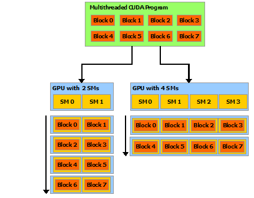

Automatic Scalability

## GPU computing

### Programming model

The CUDA programming model has 3 abstractions:

- Kernels (GPU functions)
- Thread groups
- Memory hierachy

## GPU computing

### Basic program steps

The utilize GPUs, all programs must perform the same steps as noted in the calling libraries section:

- allocate GPU memory
- transfer data to GPU
- launch GPU kernel (operates on threads, in block/grid arrangement)
- transfer results from GPU
- clean up

Note, the kernel is the basic unit of operation. This is the program function that is parallelized across the GPU.

## CUDA Kernel

The basic execution block in a CUDA program is a kernel. Kernels are blocks of code that are executed N times in parallel by N different CUDA threads.

Each thread that executes the kernel is given a unique thread ID that is accessible within the kernel through the built-in threadIdx variable.

The triple bracket specification determines the number of threads.

```r
// Kernel definition
__global__ void VecAdd(float* A, float* B, float* C)
{
    int i = threadIdx.x;
    C[i] = A[i] + B[i];
}
int main()
{
    ... // Kernel invocation with N threads
    VecAdd<<<1, N>>>(A, B, C);
    ...
}
```

## Thread hierarchy

**threads**  
For convenience, threads can be organized in 1-, 2-, or 3-d blocks.

There is a limit to the number of threads per block, since all threads of a block are expected to reside on the same processor core and must share the limited memory resources of that core. On current GPUs, a thread block may contain up to 1024 threads.

However, a kernel can be executed by multiple equally-shaped thread blocks, so that the total number of threads is equal to the number of threads per block times the number of blocks.

**blocks**  
Blocks are organized into 1-, 2-, or 3-d grid of thread blocks as illustrated on next slide. The number of thread blocks in a grid is usually dictated by the size of the data being processed or the number of processors in the system, which it can greatly exceed.

## Grid - block -thread

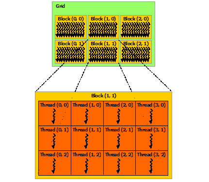

Grid-block-thread